# ggplot 2 basics

The following slides contain codes to create cool graphics that can be utilized in the IDS course.

# Boxplots and color scores

Use the command below to load the colors_ids dataset:

```r
extra_data("colors_ids")
```

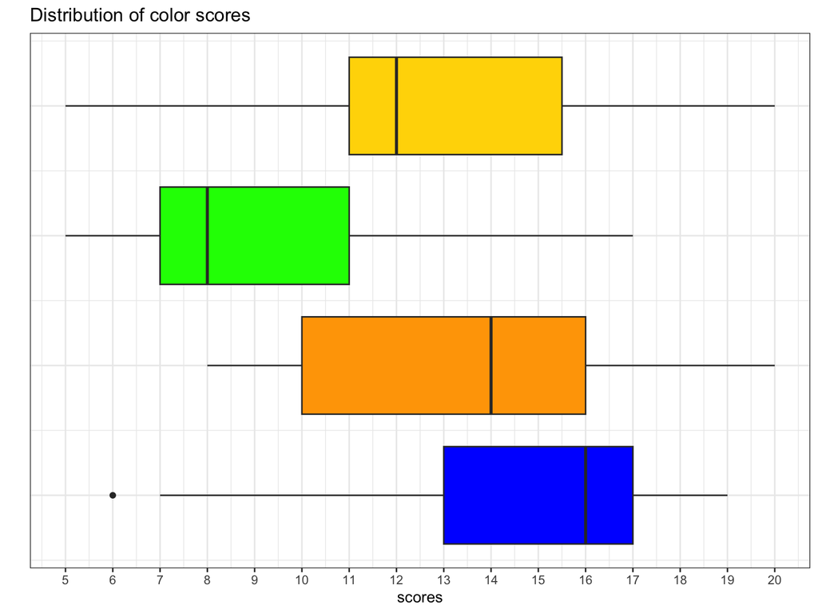

```r
ggplot(data=colors_ids)+
  geom_boxplot(mapping=aes(x=blue), fill="blue")+
  #need to change the value of y so plots don't overlap
  geom_boxplot(mapping=aes(x=orange, y=1), fill="orange")+
  geom_boxplot(mapping=aes(x=green, y=2), fill="green")+
  geom_boxplot(mapping=aes(x=gold, y=3), fill="gold")+
  #show values on the x-axis
  scale_x_continuous(breaks=seq(5,20,1))+
  labs(title="Distribution of color scores",x="scores", y="")+
  theme_bw()+
  #hides the y-axis labels
  theme(axis.text.y=element_blank(),
        axis.ticks.y=element_blank())
```

# Boxplots and dotplots

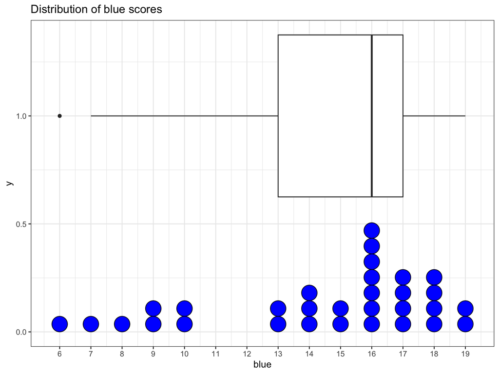

```r
ggplot(data=colors_ids)+
  geom_boxplot(mapping=aes(x=blue, y=1))+
  scale_x_continuous(breaks=seq(5,20,1))+
  labs(title="Distribution of blue scores")+
  theme_bw()+
  geom_dotplot(mapping=aes(x=blue),fill="blue",binwidth = 0.5)
```

# Bargraphs and faceting

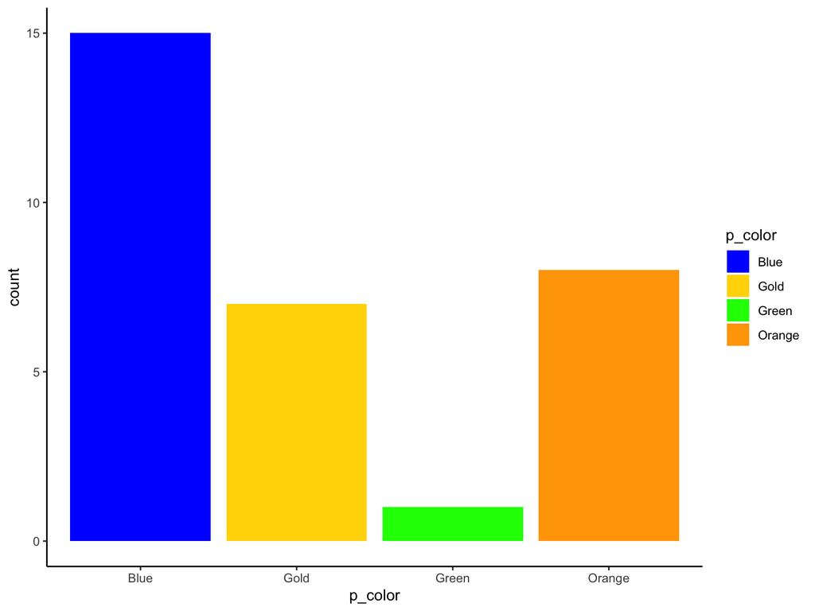

```r
ggplot(data=colors_ids)+
  geom_bar(mapping=aes(x=p_color, fill=p_color))+
  scale_fill_manual(values=c("blue", "gold", "green","orange"))+
  theme_classic()
```

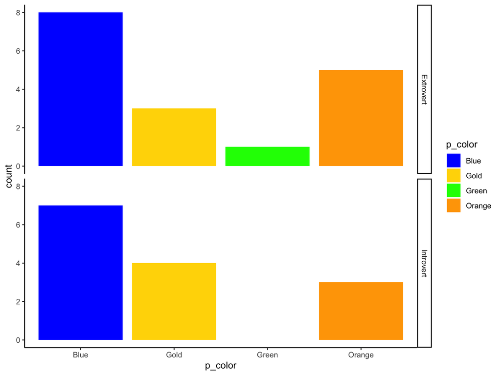

```r
ggplot(data=colors_ids)+
  geom_bar(mapping=aes(x=p_color, fill=p_color))+
  scale_fill_manual(values=c("blue", "gold", "green","orange"))+
  theme_classic()+
  facet_grid(rows=vars(int_ext))
```

```r
  #replace `rows` with `cols` above
```

# Histograms and faceting

When we plot height data faceted by gender using `cdc`, we get an extra plot where gender is NA. To get rid of that extra plot, use the following code to extract those observations:

```r
cdc2<-filter(cdc, !is.na(gender))
```

- The following code chunk is used to generate a histogram.
- The second line of code calls the arguments needed (variable, “fill” is equivalent to our “groups” function).
- The `scale_fill_manual()` function allows us to choose our colors, `facet_wrap()` stacks the histograms, `labs()` are used for the different labels and the `theme_minimal()` cleans it up.

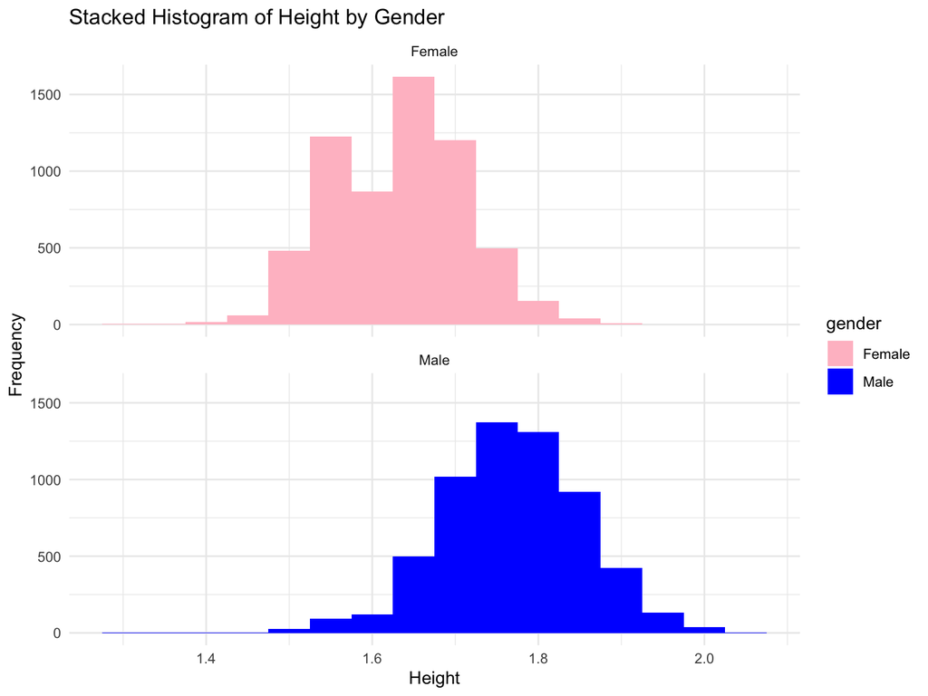

```r
ggplot(data=cdc2) +
  geom_histogram(mapping=aes(x = height, fill = gender),binwidth=0.05) +
  scale_fill_manual(values = c("pink", "blue")) +
  facet_wrap(~ gender, ncol = 1) +
  labs(x = "Height", y = "Frequency", title = "Stacked Histogram of Height by Gender") +
  theme_minimal()
```

# Scatterplots

The scatterplot below has 90 data points but because some of the armspans and corresponding heights overlap there appear to be less.

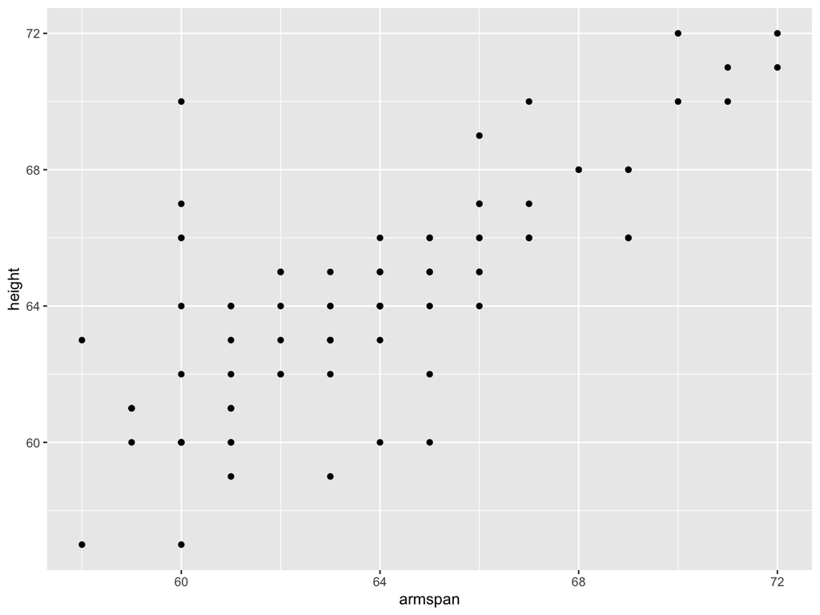

```r
ggplot(data=arm_span)+
  geom_point(mapping=aes(x=armspan, y= height))
```

A solution to this problem is to utilize the `geom_jitter` function.

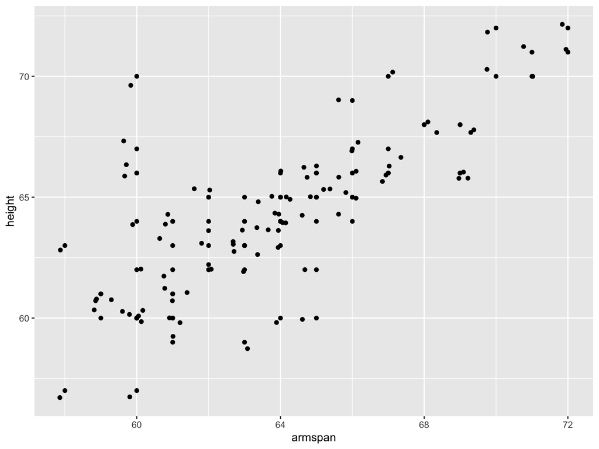

```r
ggplot(data=arm_span)+
  geom_point(mapping=aes(x=armspan, y= height))+
  geom_jitter(mapping=aes(x=armspan, y= height))
```

Alternative code

```r
ggplot(data=arm_span, mapping=aes(x=armspan, y= height))+
  geom_point()+
  geom_jitter()
```

# On Your Own

Choose one of the plots from this lab and make at least 3 modifications to it.

Here are some other themes you can choose from:

- theme_gray()
- theme_dark()
- theme_light()
- theme_linedraw()
- theme_minimal()
- theme_void()